# Reproducible Research: Peer Assessment 1

```r
# set global options
library(knitr)
opts_chunk$set(echo = TRUE, message = FALSE,  warning = FALSE, comment = NA, tidy = FALSE, fig.path = "figure/", fig.keep = "high", fig.width = 8, fig.height = 5, fig.align = "center")

# load required packages
library(dplyr, quietly=TRUE, warn.conflicts=FALSE)
library(ggplot2, quietly=TRUE, warn.conflicts=FALSE)
library(data.table, quietly=TRUE, warn.conflicts=FALSE)
```

## Loading and preprocessing the data

Now we load the data into memory, and assign the appropriate classes to the columns.

```r
activity <- read.csv("activity.csv", header = T, colClasses = c("numeric", "Date", "numeric"))
```

## What is mean total number of steps taken per day?

1. We first calculate the total number of steps taken per day (using `dplyr`).

```r
steps_per_day <- activity %>% filter(!is.na(steps)) %>% group_by(date) %>% summarise(nsteps = sum(steps))
```

2. Then we plot a histogram for the total number of steps taken per day.

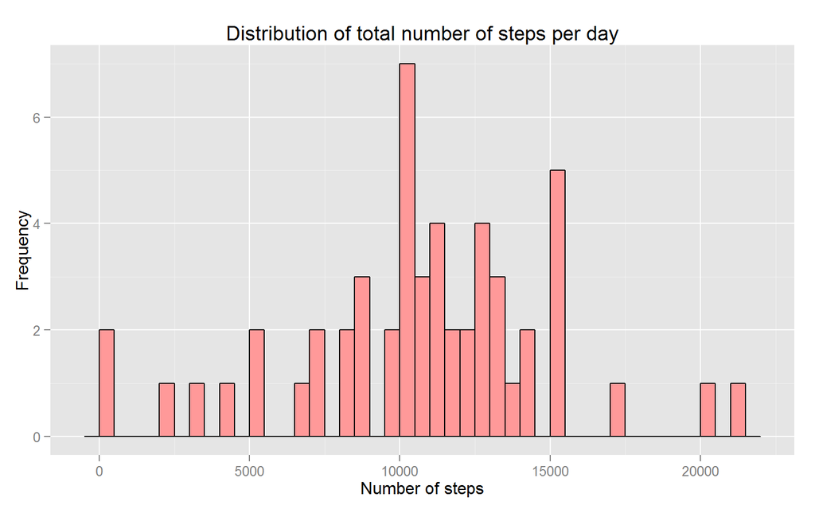

```r
ggplot(steps_per_day, aes(x = nsteps)) + geom_histogram(col = "black", fill = "#FF9999",
    binwidth = 500) + xlab("Number of steps") + ylab("Frequency") + ggtitle("Distribution of total number of steps per day")
```

3. Let’s calculate the mean and median total number of steps taken per day:

```r
stepmean <- round(mean(steps_per_day$nsteps),2)
stepmedian <- round(median(steps_per_day$nsteps), 2)
paste("Steps mean is ", stepmean, " and steps median is ", stepmedian)
```

```
[1] "Steps mean is  10766.19  and steps median is  10765"
```

## What is the average daily activity pattern?

1. At first, we summarize the data by interval accross all 53 days.

```r
daily_pattern <- activity %>% filter(!is.na(steps)) %>% group_by(interval) %>% summarise(avgsteps = mean(steps) )
```

2. Make a time series plot of mean steps per interval.

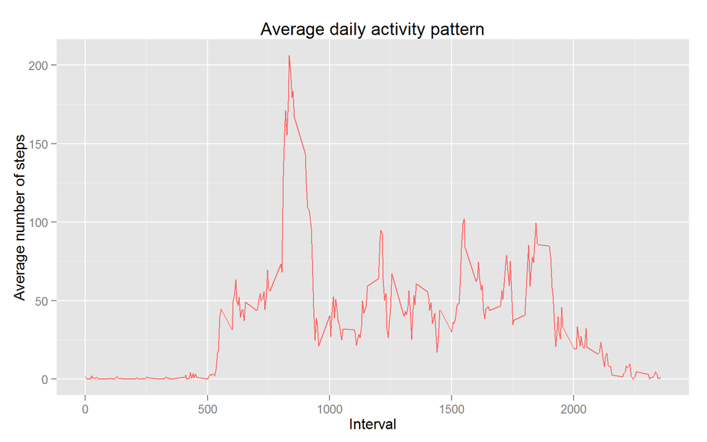

```r
ggplot(daily_pattern, aes(interval, avgsteps)) + geom_line(color = "#FF6666") +
    xlab("Interval") + ylab("Average number of steps") + ggtitle("Average daily activity pattern")
```

3. Find the interval with the maximum number of steps:

```r
daily_pattern[with(daily_pattern, avgsteps == max(avgsteps)),]$interval
```

```
[1] 835
```

## Imputing missing values

1. In the original data set, the total number of step measurements that are NA is:

```r
sum(is.na(activity$steps))
```

```
[1] 2304
```

2. Then, we fill the missing values using the median for each corresponding 5-minute interval.

```r
activity <- as.data.table(activity)
activity2 <- activity[, steps:=ifelse(is.na(.SD$steps), median(.SD$steps, na.rm = T), .SD$steps), interval]
```

3. Next, let’s explore the effect of imputing missing values in the distribution of total daily number of steps, and its mean and median.

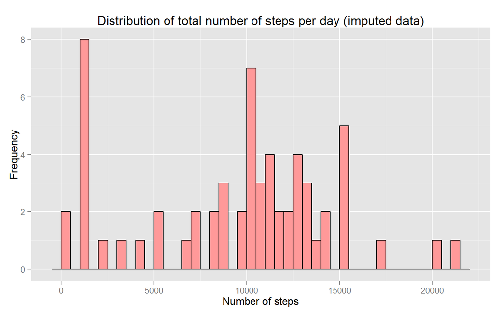

```r
steps_per_day_noNA <- activity2 %>% group_by(date) %>% summarise(nsteps = sum(steps))

ggplot(steps_per_day_noNA, aes(x = nsteps)) + geom_histogram(col = "black",
    fill = "#FF9999", binwidth = 500) + xlab("Number of steps") + ylab("Frequency") +
    ggtitle("Distribution of total number of steps per day (imputed data)")
```

```r
paste("steps mean is ", round(mean(steps_per_day_noNA$nsteps), 2), " and steps median is ",
    round(median(steps_per_day_noNA$nsteps), 2))
```

```
[1] "steps mean is  9503.87  and steps median is  10395"
```

## Are there differences in activity patterns between weekdays and weekends?

1. Firstly, we create a variable (`daytype`) with two levels – “weekday” and “weekend”.

```r
temp <- Sys.setlocale("LC_TIME", "C")
wkdays <- weekdays(activity2$date, abbreviate = T)
daytype <- ifelse(wkdays %in% c("Sat", "Sun"), "Weekend", "Weekday" )
activity2$daytype <- as.factor(daytype)
```

2. Then we calculate the average number of steps for each interval and type of day.

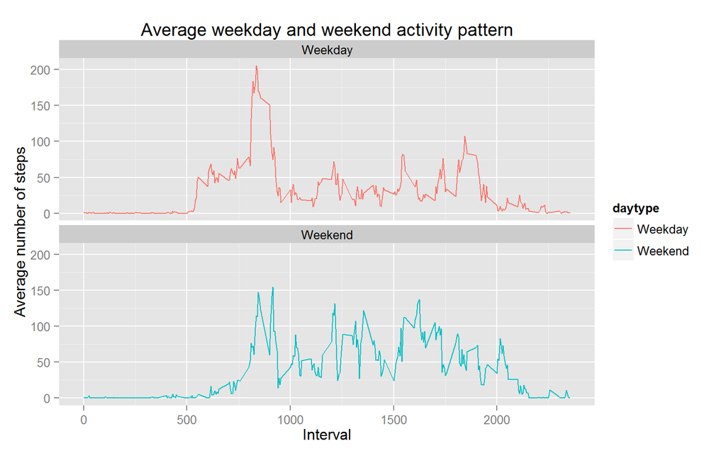

```r
weektype <- activity2 %>% group_by(daytype, interval) %>% summarise(mean = mean(steps))

ggplot(weektype, aes(interval, mean, color = daytype)) + geom_line() + facet_wrap(~daytype,
    ncol = 1) + xlab("Interval") + ylab("Average number of steps") + ggtitle("Average weekday and weekend activity pattern")
```